# Homework #5 Programming Assignment Solution

```julia
using PyPlot
```

## Basic functions

```julia
function bern(p)
    x = rand(1)[1]
    return x<p ? 1 : 0
end
function BSC(c, p)
    # input: code vector c
    # output: noisy vector y
    y = copy(c)
    for i in 1:length(c)
        y[i] += bern(p)
    end
    return y % 2
end
```

```
BSC (generic function with 1 method)
```

Generate random input bits $u\in \{0,1\}^4$ and take $c=uG$.

```julia
function genRandBitVec(k)
    # return a uniform binary (row) vector from [0:2^{k-1}]
    u = [parse(Int, s) for s in bin(rand(0:2^(k-1)), k)]'
end
```

```
genRandBitVec (generic function with 1 method)
```

Generate a codebook with a given generator matrix:

```julia
function genCodebook(G)
    k, n = size(G)
    codebook = Array{Int}(2^k, n)
    for i in 0:2^k-1
        u = [parse(Int, s) for s in bin(i, k)]'  # input bit; row vector
        codebook[i+1, :] = u*G % 2
    end
    return codebook
end
```

```
genCodebook (generic function with 1 method)
```

## Problem 1

### In this homework, we examine the performance of (7,4) Hamming code compared to other (7,4) codes over BSC$(p)$, the binary symmetric channel with bit error probability $p.$ Throughout this problem, we consider the systematic generator matrix $G$ of the following form: $G = [I_k| A ],$ where $I_k$ is the $k\times k$ identity matrix and $A$ is a $k\times(n − k)$ matrix. For example, for the (7,4) Hamming code, we consider

### $$ \begin{align*} G & = \begin{bmatrix} 1 & 0 & 0 & 0 & 1 & 1 & 0\\ 0 & 1 & 0 & 0 & 1 & 0 & 1\\ 0 & 0 & 1 & 0 & 0 & 1 & 1\\ 0 & 0 & 0 & 1 & 1 & 1 & 1\end{bmatrix}.\end{align*}$$

### In this case, recall that the parity-check matrix $H$ is obtained easily by

### $$\begin{align*} H & = [A^t | I_{n-k}].\end{align*}$$

Consider the systematic generator matrix $G = [I_{k}, A]$:

```julia
G = [1 0 0 0 1 1 0;
    0 1 0 0 1 0 1;
    0 0 1 0 0 1 1;
    0 0 0 1 1 1 1]
```

```
4×7 Array{Int64,2}:
 1  0  0  0  1  1  0
 0  1  0  0  1  0  1
 0  0  1  0  0  1  1
 0  0  0  1  1  1  1
```

```julia
codebook = genCodebook(G)
```

```
16×7 Array{Int64,2}:
 0  0  0  0  0  0  0
 0  0  0  1  1  1  1
 0  0  1  0  0  1  1
 0  0  1  1  1  0  0
 0  1  0  0  1  0  1
 0  1  0  1  0  1  0
 0  1  1  0  1  1  0
 0  1  1  1  0  0  1
 1  0  0  0  1  1  0
 1  0  0  1  0  0  1
 1  0  1  0  1  0  1
 1  0  1  1  0  1  0
 1  1  0  0  0  1  1
 1  1  0  1  1  0  0
 1  1  1  0  0  0  0
 1  1  1  1  1  1  1
```

```julia
dist = sum(codebook, 2)'
```

```
1×16 Array{Int64,2}:
 0  4  3  3  3  3  4  4  3  3  4  4  4  4  3  7
```

Then the parity check matrix can be easily obtained by $H=[A^T,I_{n-k}]$:

```julia
k, n = size(G)
H = Array{Int}(n-k, n)
H[:, 1:k] = G[:, k+1:end]'
H[:, k+1:end] = eye(n-k)
H
```

```
3×7 Array{Int64,2}:
 1  1  0  1  1  0  0
 1  0  1  1  0  1  0
 0  1  1  1  0  0  1
```

Check orthogonality: $HG^T=0$

```julia
H*G' % 2
```

```
3×4 Array{Int64,2}:
 0  0  0  0
 0  0  0  0
 0  0  0  0
```

### a) Recall that the minimum distance decoding is maximum likelihood decoding for BSC$(p)$, where $p < 1/2.$ Write a minimum distance decoder function $\texttt{mindistdec(y,C)}.$ This function takes received bits $\texttt{y}$ and a codebook $\texttt{C}$ as inputs.

```julia
function mindistdec(y, codebook)
    added = (codebook + repmat(y, size(codebook,1), 1)) % 2
    dist = sum(added, 2)
    mindist = minimum(dist)
    minidx_list = find(x->x==mindist, dist)
    return codebook[rand(minidx_list), :]'  # if there is tie, pick one at random
end
```

```
mindistdec (generic function with 1 method)
```

### b) Write a syndrome decoder function $\texttt{syndromedec(y,H)},$ which takes received bits $\texttt{y}$ and a parity check matrix $\texttt{H}$ as inputs.

```julia
function syndromedec(y)
    # input: received bits y
    # output: corrected codeword chat
    chat = copy(y)
    r = H*y' % 2
    erridx = 0
    for j = 1:7
        if norm(H[:, j] - r) < 1
            erridx = j
            break
        end
    end
    if erridx != 0
        chat[erridx] = (chat[erridx]+1) % 2
    end
    return chat
end
```

```
syndromedec (generic function with 1 method)
```

### c) For the $(7,4)$ Hamming code, verify that any one bit error in code bits can be corrected by both $\texttt{mindistdec}$ and $\texttt{syndromedec}$. Hence, for simplicity, we now use $\texttt{mindistdec}$ as our decoder for the rest of this problem.

For a sanity check of our decoders:

```julia
for i in 1:7
    z = zeros(Int64, 7)'
    z[i] = 1
    corruptedcodebook = (codebook + repmat(z, size(codebook,1), 1)) %2
    for j in 1:size(codebook, 1)
        c = corruptedcodebook[j, :]'  # row vector
        chat1 = syndromedec(c)
        chat2 = mindistdec(c, codebook)
        if codebook[j,:]' != chat1
            print("Hamming decoder is wrong!\n")
        elseif codebook[j,:]' != chat2
            print("Minimum distance decoder is wrong!\n")
        end
#         print(codebook[j,:]'==chat1, " ", codebook[j,:]'==chat2, "\n")
#         print(codebook[j,:]', " ", chat1, " ", chat2, "\n")
    end
end
```

### e) We want to run a simulation that verifies the result found in part (d). For $p = 0.05 : 0.05 : 0.5,$ do the following steps $1,000$ times to get a good estimate of the decoded word error rate (WER).

### i. Generate 4 random binary digits.

### ii. Encode them by calculating the 3 check digits, or using generator matrix G.

### iii. Put the codeword through BSC(p).

### iv. Decode the received 7-bit vector to a 4-bit word.

### v. Compare the decoded word with the transmitted word and count word errors to find word error rate (WER). Also count the errors in the information positions of the code words to obtain an estimate of the decoded bit error probability (BER).

### Plot your simulation results $p$ vs. BER$(p)$ and $p$ vs. WER$(p),$ along with the analytical expression found in part (d). Is the bit error probability larger or smaller than the word error probability?

Find error rate of a given code.

```julia
# Find BER and WER over BSC(p)
function findER(G, plist, nblock=10^4)
    k, n = size(G)
    codebook = genCodebook(G)
    ber_list = zeros(Float64, 1:length(plist))
    wer_list = zeros(Float64, 1:length(plist))
    for jj in 1:length(plist)
        p = plist[jj]
        for ii = 1:nblock
            u = genRandBitVec(k) # random input bits
            c = u*G % 2  # code bits
            y = BSC(c, p)  # received bits
            chat = mindistdec(y, codebook)  # corrected bits
            dist = sum((c[1:k]+chat[1:k])%2)
            ber_list[jj] += dist/k
            wer_list[jj] += dist>0?1:0
        end
    end
    ber_list /= nblock
    wer_list /= nblock
    return ber_list, wer_list
end
```

```
findER (generic function with 2 methods)
```

Now with (7,4) Hamming code:

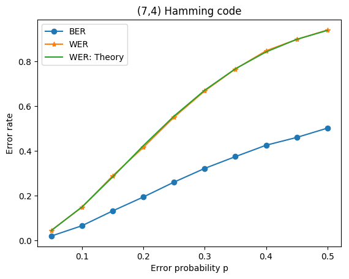

```
PyObject <matplotlib.legend.Legend object at 0x7f9504305cd0>
```

```julia
plist = 0.05:0.05:0.5
ber_list_ham, wer_list_ham = findER(G, plist, 10^4)
plot(plist, ber_list_ham, label="BER", marker="o")
plot(plist, wer_list_ham, label="WER", marker="*")
# plot(plist, 4*ber_list_ham, label="4*BER", marker="*")
plot(plist, 1-(1-plist).^6.*(1+6*plist), label="WER: Theory")
title("(7,4) Hamming code")
xlabel("Error probability p")
ylabel("Error rate")
legend(loc = "upper left", fancybox = "true")
```

### f) Now we consider another systematic generator matrix

### $$ \begin{align*} G & = \begin{bmatrix} 1 & 0 & 0 & 0 & 1 & 0 & 0\\ 0 & 1 & 0 & 0 & 0 & 1 & 0\\ 0 & 0 & 1 & 0 & 0 & 0 & 1\\ 0 & 0 & 0 & 1 & 1 & 1 & 1\end{bmatrix}.\end{align*} $$

### Repeat the same experiment as in (e), and compare the results with BER and WER of the (7,4) Hamming code.

```julia
G2 = [1 0 0 0 1 0 0;
    0 1 0 0 0 1 0;
    0 0 1 0 0 0 1;
    0 0 0 1 1 1 1]
```

```
4×7 Array{Int64,2}:
 1  0  0  0  1  0  0
 0  1  0  0  0  1  0
 0  0  1  0  0  0  1
 0  0  0  1  1  1  1
```

```julia
codebook2 = genCodebook(G2)
```

```
16×7 Array{Int64,2}:
 0  0  0  0  0  0  0
 0  0  0  1  1  1  1
 0  0  1  0  0  0  1
 0  0  1  1  1  1  0
 0  1  0  0  0  1  0
 0  1  0  1  1  0  1
 0  1  1  0  0  1  1
 0  1  1  1  1  0  0
 1  0  0  0  1  0  0
 1  0  0  1  0  1  1
 1  0  1  0  1  0  1
 1  0  1  1  0  1  0
 1  1  0  0  1  1  0
 1  1  0  1  0  0  1
 1  1  1  0  1  1  1
 1  1  1  1  0  0  0
```

The minimum distance of this code is 2.

```julia
weight = sum(codebook2, 2)'
```

```
1×16 Array{Int64,2}:
 0  4  2  4  2  4  4  4  2  4  4  4  4  4  6  4
```

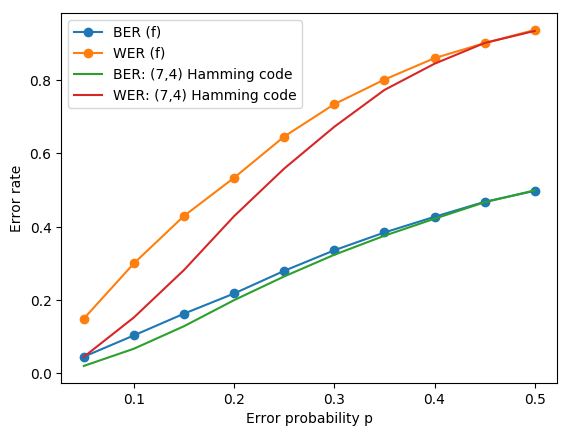

```
PyObject <matplotlib.legend.Legend object at 0x7f95045cdf50>
```

```julia
ber_list, wer_list = findER(G2, plist)
plot(plist, ber_list, label="BER (f)", marker="o")
plot(plist, wer_list, label="WER (f)", marker="o")
plot(plist, ber_list_ham, label="BER: (7,4) Hamming code")
plot(plist, wer_list_ham, label="WER: (7,4) Hamming code")
# plot(plist, 4*ber_list, label="4*BER", marker="*")
xlabel("Error probability p")
ylabel("Error rate")
legend(loc = "upper left", fancybox = "true")
```

We see that Hamming code uniformly outperforms the second code. This is expected, since $d_{\text{min}}$ for the second code is only 2 (verify this!), whereas it is 3 for Hamming.

(Hint: you might want to use the following modified minimum distance decoder.)

```julia
function mindistdec_debug(y, codebook)
    added = (codebook + repmat(y, size(codebook,1), 1)) % 2
    dist = sum(added, 2)
    mindist = minimum(dist)
    minidx_list = find(x->x==mindist, dist)
    return minidx_list  # if there is tie, pick one at random
end
```

```
mindistdec_debug (generic function with 1 method)
```

Let us verify that theory matches experiments for the second code.

```julia
coeff =  [0.0 3.0 18.0 35.0 35.0 21.0 7.0 1.0]
```

```
1×8 Array{Float64,2}:
 0.0  3.0  18.0  35.0  35.0  21.0  7.0  1.0
```

```julia
function thwer(p, coeff)
    s = zeros(length(p))
    for w in 0:length(coeff)-1
        s += coeff[w+1]*p.^w.*(1-p).^(7-w)
    end
    return s
end
```

```
thwer (generic function with 1 method)
```

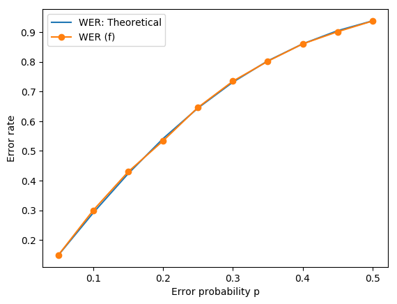

```
PyObject <matplotlib.legend.Legend object at 0x7f95044b3310>
```

```julia
plot(plist, thwer(plist, coeff), label="WER: Theoretical")
plot(plist, wer_list, label="WER (f)", marker="o")
xlabel("Error probability p")
ylabel("Error rate")
legend(loc = "upper left", fancybox = "true")
```

### g) Finally we examine the performance of a randomly generated (7, 4) systematic generator matrix. Generate a random 4×3 binary matrix $A$ and use $G = [I_4 | A]$ as our generator matrix. For each $G,$ repeat the same experiment in (e), and take averages of BERs and WERs over the random matrices. Compare the results with BER and WER of the (7,4) Hamming code. Is there any $p$ where a randomly generated $G$ performs better than the Hamming (7,4) code on average?

Generate a random systematic generator matrix $G=[I_k, A]$. We decide $A$ as a $k\times(n-k)$ random matrix where each entry is drawn from Bernoulli(1/2) independently.

```julia
niter = 10^3
avgber_list = zeros(Float64, 1:length(plist))
avgwer_list = zeros(Float64, 1:length(plist))
n, k = 7, 4
tic();
for ll = 1:niter
    A = reshape([bern(1/2) for i in 1:k*(n-k)], k, n-k)
    Grand = [eye(Int64, k) A]
    ber_list_new, wer_list_new = findER(Grand, plist, 10^2)
    avgber_list += ber_list_new
    avgwer_list += wer_list_new
end
toc();
avgber_list /= niter;
avgwer_list /= niter;
```

[output not shown]

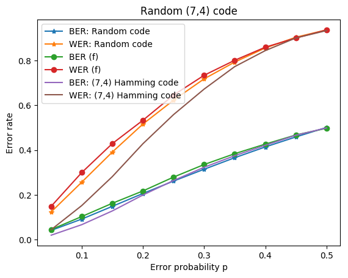

```
PyObject <matplotlib.legend.Legend object at 0x7f9504416fd0>
```

```julia
plot(plist, avgber_list, label="BER: Random code", marker="*")
plot(plist, avgwer_list, label="WER: Random code", marker="*")
plot(plist, ber_list, label="BER (f)", marker="o")
plot(plist, wer_list, label="WER (f)", marker="o")
plot(plist, ber_list_ham, label="BER: (7,4) Hamming code")
plot(plist, wer_list_ham, label="WER: (7,4) Hamming code")
title("Random (7,4) code")
xlabel("Error probability p")
ylabel("Error rate")
legend(loc = "upper left", fancybox = "true")
```

We see that Hamming code uniformly outperforms both the random code and the second code, but the random codes perform marginally better than the second code.